# Introducción

En este material veremos algunas herramientas un poco más avanzadas que sirven para escalar procedimientos que vimos anteriormente y/o para automatizar (parte de) nuestro trabajo. La idea es un primer acercamiento a herramientas que evitan tener que constantemente copiar nuestro código y modificar algunos paramentos o variables, cada vez que queramos realizar procedimientos parecidos.

```r
### Cargo librería
library(tidyverse)

##  ~ Cargo la base de trabajo  ----
base_snic <- read_csv2("../data/snic-departamentos-mes-sexo.csv")
```

# Loops

Un **loop** es una estructura de código que nos permite aplicar iterativamente un mismo conjunto de comandos, variando el valor de una variable. Veremos aquí únicamente el loop **for**, cuya sintaxis es la siguiente:

`for (variable in vector) {conjunto de procedimientos a realizar}`

```r
for(i in 1:10){
   print(i^2)

}
```

```
## [1] 1
## [1] 4
## [1] 9
## [1] 16
## [1] 25
## [1] 36
## [1] 49
## [1] 64
## [1] 81
## [1] 100
```

Esto se lee como : “Recorre cada uno de los valores (i) del vector numérico 1 a 10, y para cada uno de ellos imprimí el cuadrado (i^2)”.  
Uno puede especificar la palabra que desee que tomé cada uno de los valores que debe tomar. En el ejemplo anterior fue **i**, pero bien podría ser la “**Valores**”

```r
for(Valores in 1:10){
   print(Valores^2)

}
```

```
## [1] 1
## [1] 4
## [1] 9
## [1] 16
## [1] 25
## [1] 36
## [1] 49
## [1] 64
## [1] 81
## [1] 100
```

Un loop puede iterar sobre cualquier tipo de vector, independientemente de lo que contenga.

**Una utilización típica de los loops**: Recorrer las categorías de una variable y hacer el mismo gráfico para cada una de ellas.

```r
tabla <- base_snic %>%
  group_by(provincia_nombre) %>%
  summarise(cantidad_victimas = sum(cantidad_victimas, na.rm = TRUE))
```

```r
categorias_prov <- unique(tabla$provincia_nombre)
categorias_prov
```

```
##  [1] "Buenos Aires"
##  [2] "Catamarca"
##  [3] "Chaco"
##  [4] "Chubut"
##  [5] "Ciudad Autónoma de Buenos Aires"
##  [6] "Córdoba"
##  [7] "Corrientes"
##  [8] "Entre Ríos"
##  [9] "Formosa"
## [10] "Jujuy"
## [11] "La Pampa"
## [12] "La Rioja"
## [13] "Mendoza"
## [14] "Misiones"
## [15] "Neuquén"
## [16] "Río Negro"
## [17] "Salta"
## [18] "San Juan"
## [19] "San Luis"
## [20] "Santa Cruz"
## [21] "Santa Fe"
## [22] "Santiago del Estero"
## [23] "Tierra del Fuego, Antártida e Islas del Atlántico Sur"
## [24] "Tucumán"
## [25] NA
```

**Recomendación:** Antes de hacer un loop (ya sea para gráficos u otros procesamientos), prueben primero obtener lo que quieren para una categoría, y luego lo extienden hacia el resto. En este sentido, armemos el gráfico para la categoría “Tucumán”

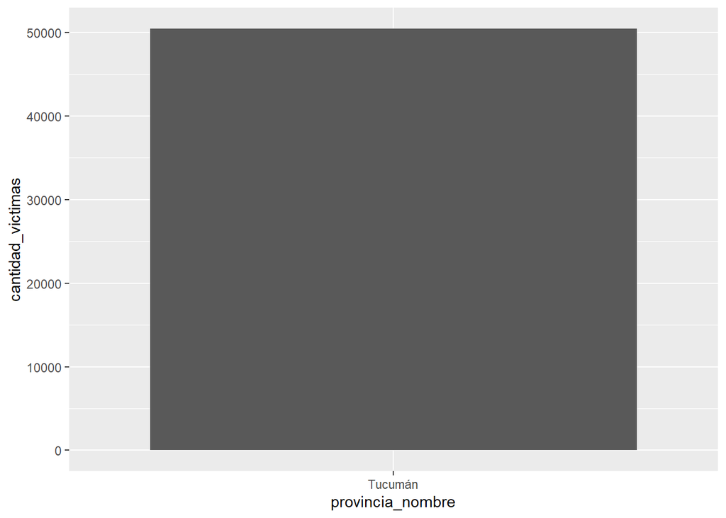

```r
tabla_tucumán  <- tabla %>%
    filter(provincia_nombre == "Tucumán")

ggplot(data = tabla_tucumán,
       aes(x = provincia_nombre, y = cantidad_victimas)) +
  geom_col()
```

Una vez que tenemos el gráfico que nos gusta, ahora si armemos el *loop*.

Miren las diferecias entre el código anterior y el siguiente:

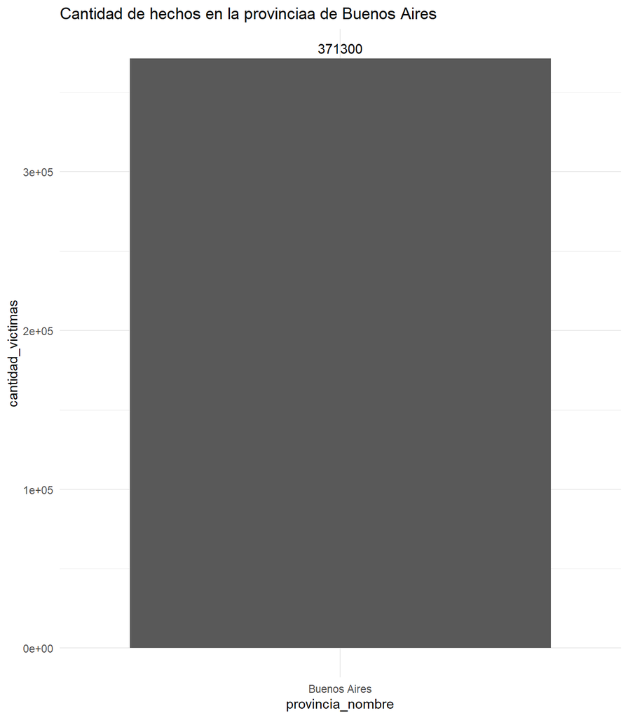

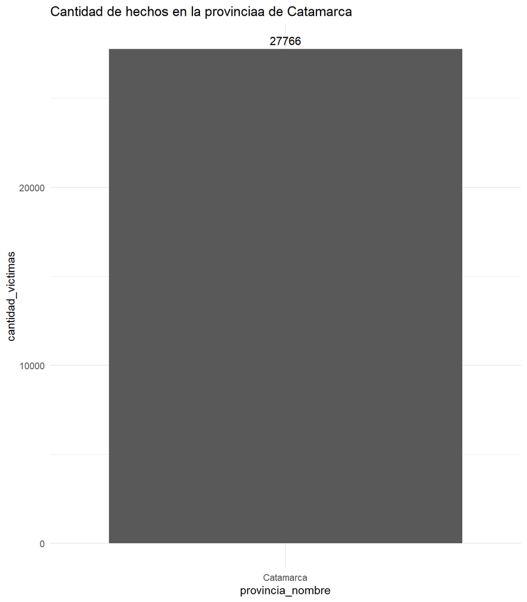

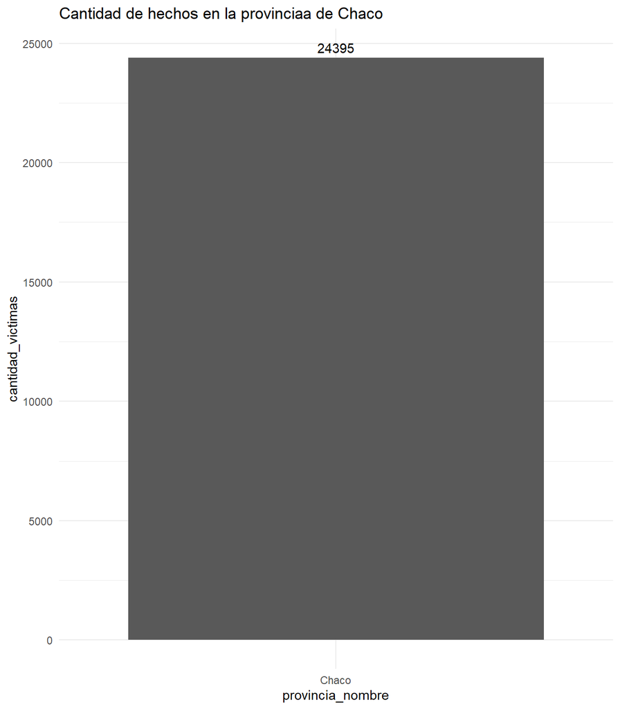

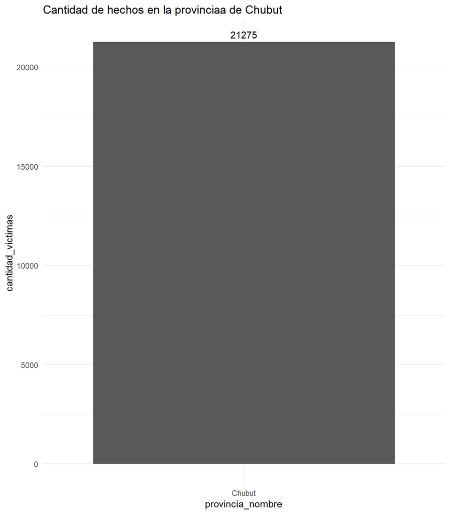

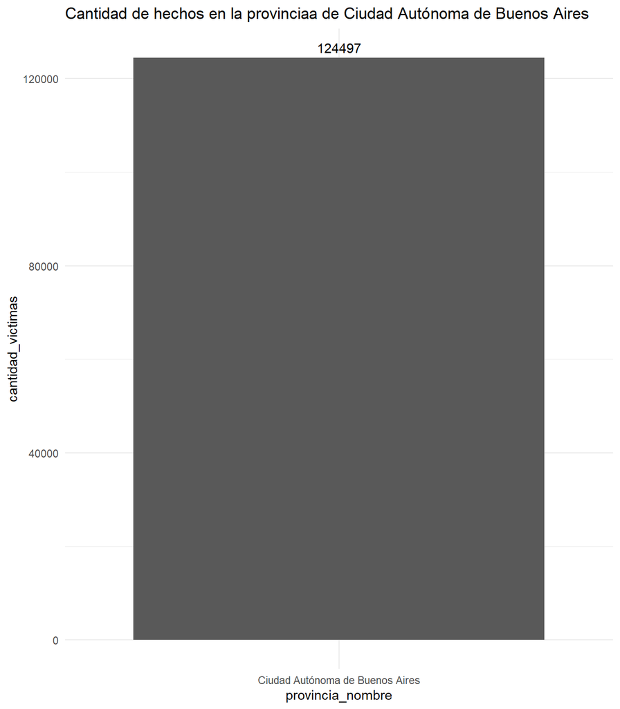

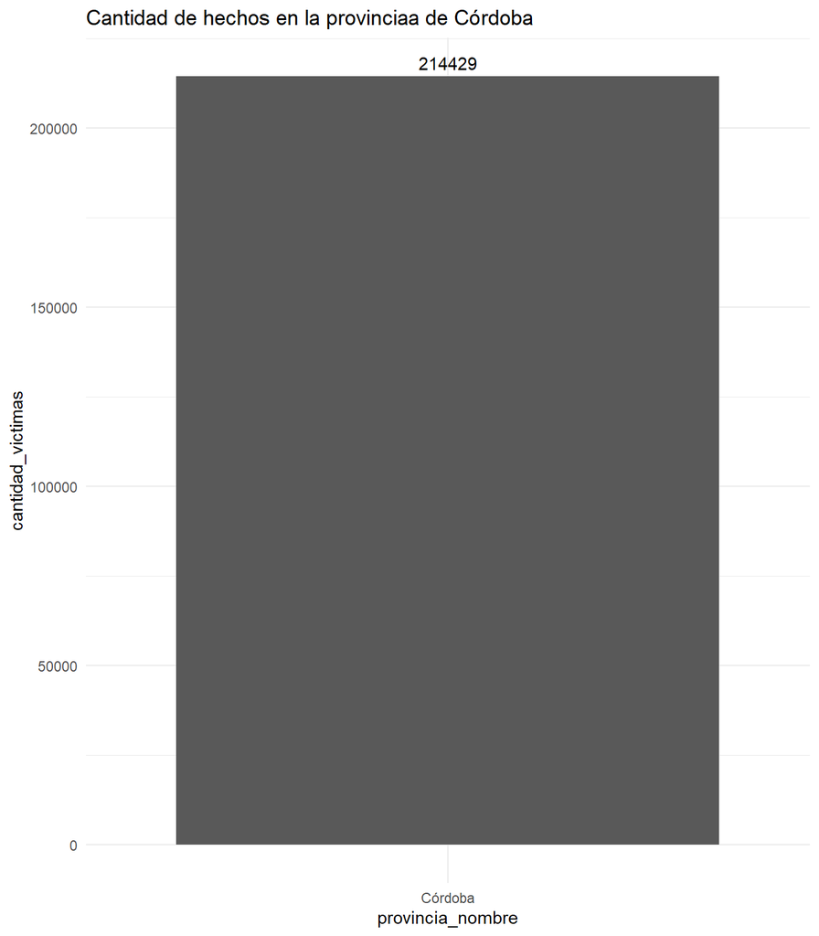

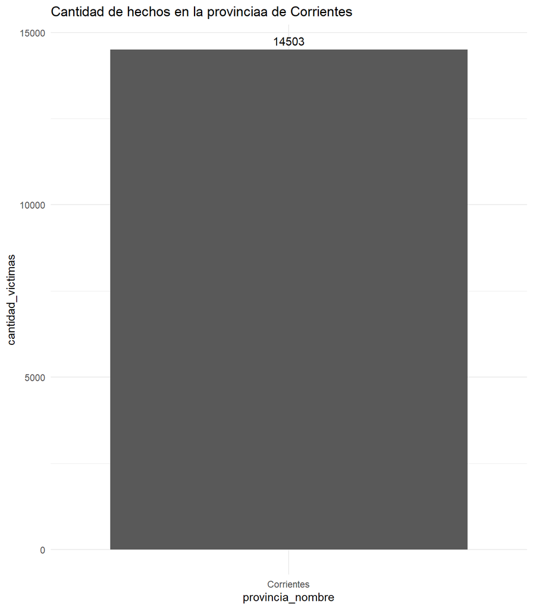

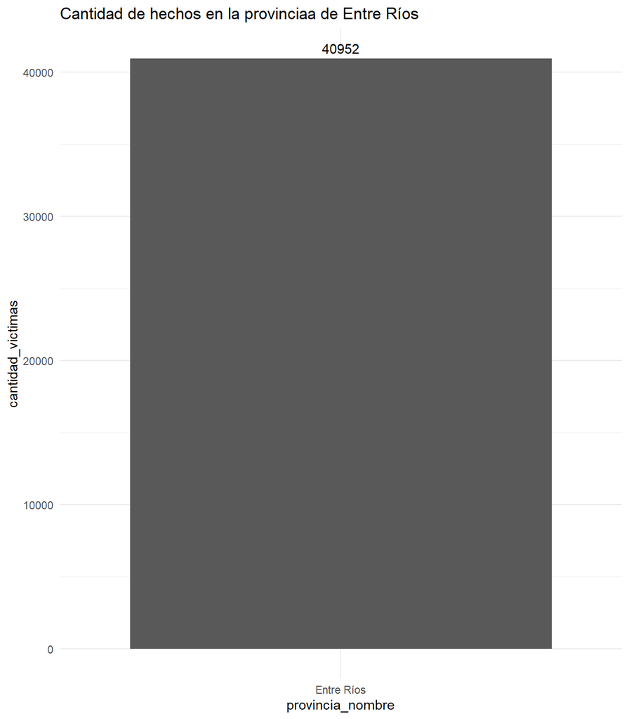

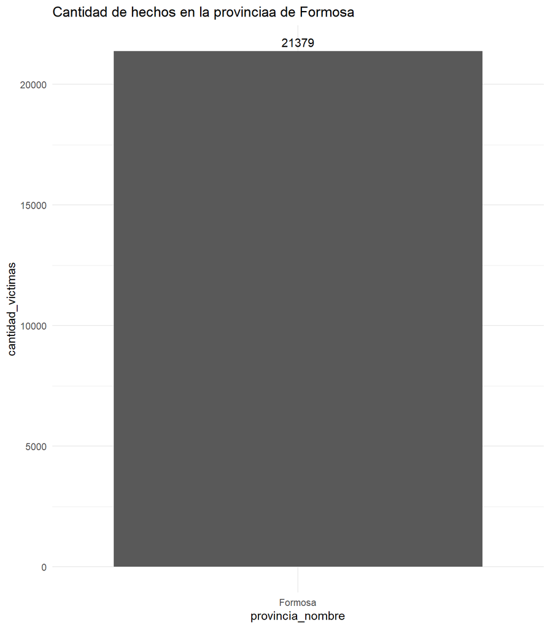

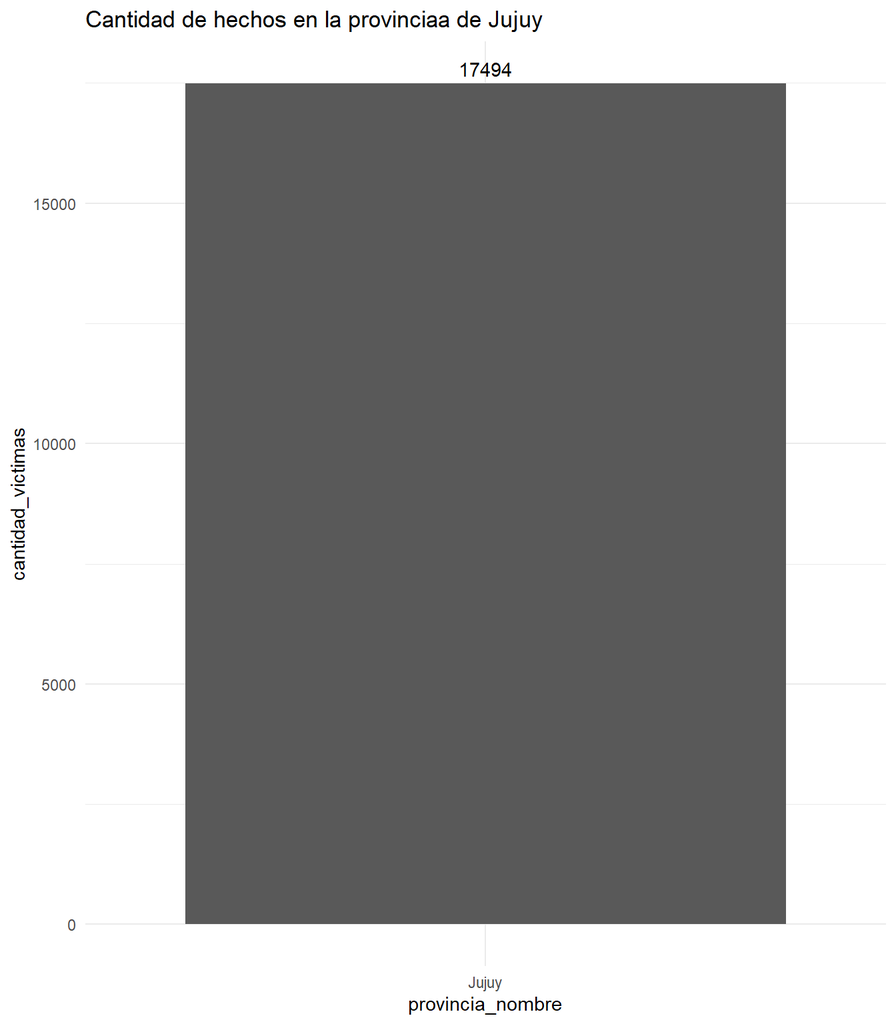

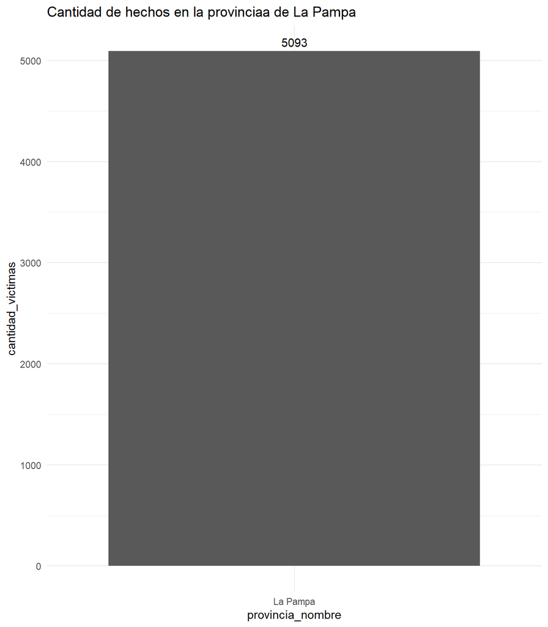

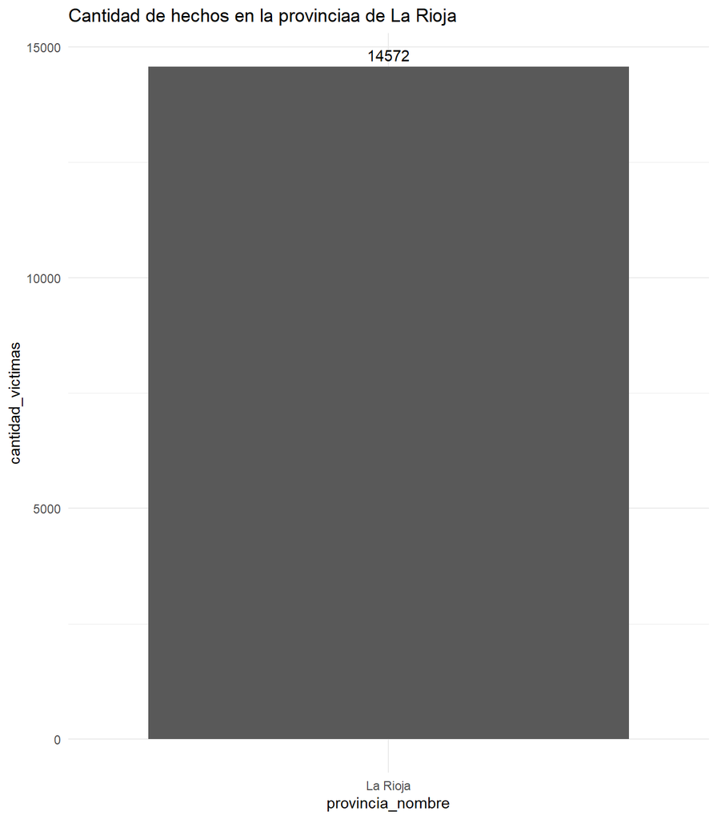

[13 more figures not shown]

```r
for(provincia in categorias_prov){

  tabla_grafico <- tabla %>%
    filter(provincia_nombre == provincia)

  grafico <- ggplot(data = tabla_grafico,
         aes(x = provincia_nombre, y = cantidad_victimas)) +
    geom_col() +
    geom_text(aes(label = cantidad_victimas),
              vjust = -0.5) +
    labs(title = paste0("Cantidad de hechos en la provinciaa de ", provincia)) +
    theme_minimal()

  print(grafico)

}
```